# Practical Machine Learning Course Project

Robert Davis

Saturday, March 21, 2015

## Background

Using devices such as Jawbone Up, Nike FuelBand, and Fitbit it is now possible to collect a large amount of data about personal activity relatively inexpensively. These type of devices are part of the quantified self movement - a group of enthusiasts who take measurements about themselves regularly to improve their health, to find patterns in their behavior, or because they are tech geeks. One thing that people regularly do is quantify how much of a particular activity they do, but they rarely quantify how well they do it. In this project, your goal will be to use data from accelerometers on the belt, forearm, arm, and dumbell of 6 participants. They were asked to perform barbell lifts correctly and incorrectly in 5 different ways. More information is available from the website here: http://groupware.les.inf.puc-rio.br/har (see the section on the Weight Lifting Exercise Dataset).

## Data Source

The training data for this project are available here:

https://d396qusza40orc.cloudfront.net/predmachlearn/pml-training.csv

The test data are available here:

https://d396qusza40orc.cloudfront.net/predmachlearn/pml-testing.csv

The data for this project comes from this original source: http://groupware.les.inf.puc-rio.br/har. If you use the document you create for this class for any purpose please cite them as they have been very generous in allowing their data to be used for this kind of assignment.

## Project Summary

The goal of your project is to predict the manner in which they did the exercise. This is the “classe” variable in the training set. You may use any of the other variables to predict with. You should create a report describing how you built your model, how you used cross validation, what you think the expected out of sample error is, and why you made the choices you did. You will also use your prediction model to predict 20 different test cases.

Your submission should consist of a link to a Github repo with your R markdown and compiled HTML file describing your analysis. Please constrain the text of the write up to < 2000 words and the number of figures to be less than 5. It will make it easier for the graders if you submit a repo with a gh-pages branch so the HTML page can be viewed online (and you always want to make it easy on graders :-). You should also apply your machine learning algorithm to the 20 test cases available in the test data above. Please submit your predictions in appropriate format to the programming assignment for automated grading. See the programming assignment for additional details.

## Reproduceability

In order to reproduce the results from this report, the following packages will need to installed into the working environment.

- install.packages(“caret”)
- install.packages(“rpart”)
- install.packages(“rpart.plot”)
- install.packages(“rattle”)
- install.packages(“randomForest”)

The following Libraries are used for this project.

```r
library(caret)
library(rpart)
library(rpart.plot)
library(rattle)
library(randomForest)
```

The pseudo random seed should also be set as follows.

```r
set.seed(1964)
```

## Load the data

Load the training and test data sets from the URL’s for reproducability.

```r
## Get the URL's
trainUrl <- "http://d396qusza40orc.cloudfront.net/predmachlearn/pml-training.csv"
testUrl  <- "http://d396qusza40orc.cloudfront.net/predmachlearn/pml-testing.csv"

## Load the data and clean up the NA data
trainingSet <- read.csv(url(trainUrl), na.strings=c("NA","#DIV/0!",""))
testingSet <- read.csv(url(testUrl), na.strings=c("NA","#DIV/0!",""))
```

## Modeling Rational

The outcome variable classe is a factor variable with 5 levels. For this data set, participants were asked to perform one set of 10 repetitions of the Unilateral Dumbbell Biceps Curl in 5 different fashions:

- exactly according to the specification (Class A)
- throwing the elbows to the front (Class B)
- lifting the dumbbell only halfway (Class C)
- lowering the dumbbell only halfway (Class D)
- throwing the hips to the front (Class E)

Class A corresponds to the specified execution of the exercise, while the other 4 classes correspond to common mistakes.

Prediction evaluations will be based on maximizing the accuracy and minimizing the out-of-sample error. All other available variables after cleaning will be used for prediction. Two models will be tested, the decision tree and the random forest algorithms. The model with the highest accuracy will be chosen as our final model.

## Cross-validation

There is a large sample size with N = 19622 samples in the Training data set. Thus, the training set can be divided to allow for cross-validation. Cross-validation will be performed by sampling the training data set randomly without replacement into 2 subsets: cvTraining data (60% of the original Training data set) and cvTesting data (40% of the original Training data set). The models will be fitted on the cvTraining data set, and tested on the cvTesting data. Once the most accurate model is chosen, it will be tested on the original Testing data set.

## Expected Error

The expected out-of-sample error will correspond to 1-accuracy in the cross-validation data. Accuracy is the proportion of correct classified observation over the total sample in the subTesting data set. Expected accuracy is the expected accuracy in the out-of-sample data set (i.e. original testing data set). Thus, the expected value of the out-of-sample error will correspond to the expected number of (missclassified observations)/(total observations) in the Test data set, which is equal 1-accuracy found from the cross-validation data set.

## Cleaning the data

Remove variables that are irrelevant to the current project.

```r
trainingSet <- trainingSet[c(-1)]
trainingSet <-trainingSet[,-c(1:7)]
testingSet  <- testingSet[c(-1)]
testingSet  <-testingSet[,-c(1:7)]
```

Remove NA and other useless empty variables.

```r
NAindex <- apply(trainingSet,2,function(x) {sum(is.na(x))})
trainingSet <- trainingSet[,which(NAindex == 0)]
NAindex <- apply(testingSet,2,function(x) {sum(is.na(x))})
testingSet <- testingSet[,which(NAindex == 0)]
```

Remove variables with values near zero, that are not meaning in the predictions.

```r
nzv <- nearZeroVar(trainingSet,saveMetrics=TRUE)
trainingSet <- trainingSet[,nzv$nzv==FALSE]

nzv <- nearZeroVar(testingSet,saveMetrics=TRUE)
testingSet <- testingSet[,nzv$nzv==FALSE]
```

## Create Cross-validation Sets

In order to perform cross-validation, the training data set is partitioned into 2 sets: cvTraining (60%) and cvTesting (40%). This will be performed using random subsampling without replacement.

```r
samples    <- createDataPartition(y=trainingSet$classe, p=0.6, list=FALSE)
cvTraining <- trainingSet[samples, ]
cvTesting  <- trainingSet[-samples, ]
```

## Prediction model 1: Decision Tree

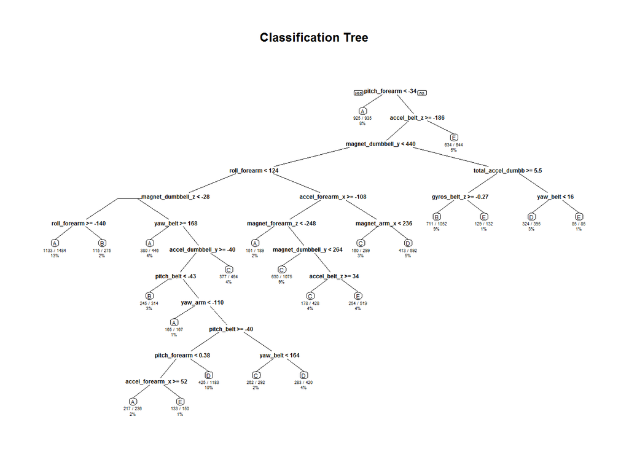

```r
model1 <- rpart(classe ~ ., data=cvTraining, method="class")
prediction1 <- predict(model1, cvTesting, type = "class")

# Plot of the Decision Tree
rpart.plot(model1, main="Classification Tree", extra=102, under=TRUE, faclen=0)
```

## Results from the cvTesting Data Set:

```r
confusionMatrix(prediction1, cvTesting$classe)
```

```
## Confusion Matrix and Statistics
##
##           Reference
## Prediction    A    B    C    D    E
##          A 1981  239   20   78   33
##          B   52  707   61   78  178
##          C   40  222 1081  145  232
##          D  137  232  198  925  202
##          E   22  118    8   60  797
##
## Overall Statistics
##
##                Accuracy : 0.6998
##                  95% CI : (0.6896, 0.71)
##     No Information Rate : 0.2845
##     P-Value [Acc > NIR] : < 2.2e-16
##
##                   Kappa : 0.6206
##  Mcnemar's Test P-Value : < 2.2e-16
##
## Statistics by Class:
##
##                      Class: A Class: B Class: C Class: D Class: E
## Sensitivity            0.8875  0.46574   0.7902   0.7193   0.5527
## Specificity            0.9341  0.94169   0.9014   0.8828   0.9675
## Pos Pred Value         0.8426  0.65706   0.6285   0.5460   0.7930
## Neg Pred Value         0.9543  0.88021   0.9532   0.9413   0.9057
## Prevalence             0.2845  0.19347   0.1744   0.1639   0.1838
## Detection Rate         0.2525  0.09011   0.1378   0.1179   0.1016
## Detection Prevalence   0.2996  0.13714   0.2192   0.2159   0.1281
## Balanced Accuracy      0.9108  0.70372   0.8458   0.8010   0.7601
```

## Prediction model 2: Random Forest

```r
model2 <- randomForest(classe ~. , data=cvTraining, method="class")
prediction2 <- predict(model2, cvTesting, type = "class")
```

## Test results on cvTesting data set:

```r
confusionMatrix(prediction2, cvTesting$classe)
```

```
## Confusion Matrix and Statistics
##
##           Reference
## Prediction    A    B    C    D    E
##          A 2231   11    0    0    0
##          B    0 1506    8    0    0
##          C    0    1 1358   18    0
##          D    0    0    2 1267    6
##          E    1    0    0    1 1436
##
## Overall Statistics
##
##                Accuracy : 0.9939
##                  95% CI : (0.9919, 0.9955)
##     No Information Rate : 0.2845
##     P-Value [Acc > NIR] : < 2.2e-16
##
##                   Kappa : 0.9923
##  Mcnemar's Test P-Value : NA
##
## Statistics by Class:
##
##                      Class: A Class: B Class: C Class: D Class: E
## Sensitivity            0.9996   0.9921   0.9927   0.9852   0.9958
## Specificity            0.9980   0.9987   0.9971   0.9988   0.9997
## Pos Pred Value         0.9951   0.9947   0.9862   0.9937   0.9986
## Neg Pred Value         0.9998   0.9981   0.9985   0.9971   0.9991
## Prevalence             0.2845   0.1935   0.1744   0.1639   0.1838
## Detection Rate         0.2843   0.1919   0.1731   0.1615   0.1830
## Detection Prevalence   0.2858   0.1930   0.1755   0.1625   0.1833
## Balanced Accuracy      0.9988   0.9954   0.9949   0.9920   0.9978
```

## Classification Submission

```r
# predict outcome levels on the original Testing data set using Random Forest algorithm
predictfinal <- predict(model2, testingSet, type="class")
predictfinal
```

```
##  1  2  3  4  5  6  7  8  9 10 11 12 13 14 15 16 17 18 19 20
##  B  A  B  A  A  E  D  B  A  A  B  C  B  A  E  E  A  B  B  B
## Levels: A B C D E
```

```r
# Write files for submission
pml_write_files = function(x){
  n = length(x)
  for(i in 1:n){
    filename = paste0("problem_id_",i,".txt")
    write.table(x[i],file=filename,quote=FALSE,row.names=FALSE,col.names=FALSE)
  }
}

pml_write_files(predictfinal)
```